# Taller 3

Estefanía Laverde, Maria Fernanda Palacio, David Alsina

3/8/2022

### 1. Find the maximum likelihood estimates of the 2 × 1 mean vector µ and the 2 × 2 covariance matrix Σ based on the random sample.

primero observemos el MLE para $\mu$:

```r
X1 = cbind(c(3, 4, 5, 4), c(6, 4, 7, 7))
X1 = data.frame(X1)

x1_mu = colMeans(X1)
x1_mu
```

```
## X1 X2
##  4  6
```

Ahora el MLE para $\Sigma$:

```r
x1_sigma = cov(X1) * (nrow(X1) - 1)/nrow(X1)
x1_sigma
```

```
##      X1   X2
## X1 0.50 0.25
## X2 0.25 1.50
```

### 2. Using the data

$$X = \begin{bmatrix}
2 & 12\\
8 & 9\\
6 & 9\\
8 & 10\\
\end{bmatrix}$$

```r
X2 = cbind(c(2, 8, 6, 8), c(12, 9, 9, 10))
X2 = data.frame(X2)
```

*A) Evaluate $T^{2}$, for testing $H_0$ : $\mu′ = [7, \; 11]$ , using the data* library(matlib)

```r
m0 = c(7, 11)
mu = colMeans(X2)
n = nrow(X2)

# recuerde que r usa la versión incesgada (1/n-1)
s = cov(X2)* ((n-1)/(n))

t_calc = n*rbind(mu - m0) %*% solve( s ) %*% t(rbind(mu - m0))
t_calc
```

```
##          [,1]
## [1,] 18.18182
```

*B) Specify the distribution of $T^{2}$ for the situation in (A).*

Dado que solo tenemos 4 mediciones por cada variable *(nuestro numero de datos es pequeño)* entonces $T^{2}$ debe seguir una distribución $F_{p, \; n - p} = F_{2, 2}$ grados de libertad.

*C) Using (A) and (B), test H0 at the $\alpha = .05$ level. What conclusion do you reach?*

```r
n = nrow(X2)
p = ncol(X2)

alpha = 0.05
t_val = qf(p = 1- (alpha/2), df1 = p, df2 = n-p, lower.tail = FALSE) * ((n-1)*p)/(n-p)

abs(t_calc) > t_val
```

```
##      [,1]
## [1,] TRUE
```

Rechazamos $H_{0}$ ya que supera el valor t calculado.

*D) Determine $\Lambda$*

```r
sigma_g1 = (3/4) * cov(X2)
s11 = 1/4*((2-7)+(8-7)+(6-7)+(8-7))^2
s22 = 1/4*((12-11)+(9-11)+(9-11)+(10-11))^2
s12 = 1/4*(2-7)*(12-11)+(8-7)*(9-11)+(6-7)*(9-11)+(8-7)*(10-11)
s21 = s12
sigma_m0 = rbind(c(s11,s12),c(s21,s22))

Lambda = (det(sigma_g1)/det(sigma_m0))^2
Lambda
```

```
## [1] 0.06321633
```

*E) Calcule $T^2$ usando Lambda de Wilk*

```r
T2 = 3*((1/sqrt(Lambda))-1)
T2
```

```
## [1] 8.931818
```

3.Harry Roberts, a naturalist for the Alaska Fish and Game department, studies grizzly bears with the goal of maintaining a healthy population. Measurements on $n = 61$ bears provided the following summary statistics:

$$S = \begin{bmatrix}
3266.46 & 1343.97 & 731.54 & 1175.50 & 162.68 & 238.37\\
1343.97 & 721.91 & 324.25 & 537.35 & 80.17 & 117.73\\
731.54 & 324.25 & 179.28 & 281.17 & 39.15 & 56.80 \\
1175.50 & 537.35 & 281.17 & 474.98 & 63.73 & 94.85\\
162.68 & 80.17 & 39.15 & 63.73 & 9.95 & 13.88\\
238.37 & 117.73 & 56.80 & 94.85 & 13.88 & 21.26\\
\end{bmatrix}$$

```r
S = matrix(c(3266.46, 1343.97, 731.54, 1175.50, 162.68, 238.37,
             1343.97, 721.91, 324.25, 537.35, 80.17, 117.73,
             731.54, 324.25, 179.28, 281.17, 39.15, 56.80,
             1175.50, 537.35, 281.17, 474.98, 63.73, 94.85,
             162.68, 80.17, 39.15, 63.73, 9.95, 13.88,
             238.37, 117.73, 56.80, 94.85, 13.88, 21.26),byrow=FALSE,ncol=6)

x_barra = matrix(c(95.52, 164.38, 55.69, 93.39, 17.98, 31.13), byrow = FALSE, ncol = 6)

p = ncol(S)
n = 61
```

*A) Obtain the large sample $95%$ simultaneous confidence intervals for the six population mean body measurements*

```r
a = matrix(c(1, 0, 0, 0, 0, 0,
             0, 1, 0, 0, 0, 0,
             0, 0, 1, 0, 0, 0,
             0, 0, 0, 1, 0, 0,
             0, 0, 0, 0, 1, 0,
             0, 0, 0, 0, 0, 1),byrow=FALSE,ncol=6)

alpha = 0.05

#*t(a1)%*%S%*%a1)

ui = c()
li = c()
for (i in 1:nrow(a)){
  ui <- append(ui, x_barra[i] + sqrt((p*(n-1))/(n*(n-p))*qf(1-alpha,p,n-p)*t(a[i,])%*%S%*%a[i,]))

  li <- append(li, x_barra[i] - sqrt((p*(n-1))/(n*(n-p))*qf(1-alpha,p,n-p)*t(a[i,])%*%S%*%a[i,]))

}

ui
```

```
## [1] 123.71901 177.63674  62.29634 104.14308  19.53635  33.40498
```

```r
li
```

```
## [1]  67.32099 151.12326  49.08366  82.63692  16.42365  28.85502
```

*B) Obtain the large sample $95%$ confidence ellipse for mean weight and mean girth.*

```r
x1 = c(3266.46, 1343.97, 731.54, 1175.50, 162.68, 238.37)
x2 = c(1343.97, 721.91, 324.25, 537.35, 80.17, 117.73)
x3 = c(731.54, 324.25, 179.28, 281.17, 39.15, 56.80)
x4 = c(1175.50, 537.35, 281.17, 474.98, 63.73, 94.85)
x5 = c(162.68, 80.17, 39.15, 63.73, 9.95, 13.88)
x6 = c(238.37, 117.73, 56.80, 94.85, 13.88, 21.26)

S = data.frame(x1, x2, x3, x4, x5, x6)
S
```

```
##        x1      x2     x3      x4     x5     x6
## 1 3266.46 1343.97 731.54 1175.50 162.68 238.37
## 2 1343.97  721.91 324.25  537.35  80.17 117.73
## 3  731.54  324.25 179.28  281.17  39.15  56.80
## 4 1175.50  537.35 281.17  474.98  63.73  94.85
## 5  162.68   80.17  39.15   63.73   9.95  13.88
## 6  238.37  117.73  56.80   94.85  13.88  21.26
```

```r
sub_s = matrix( c(S[1,1], S[4,1], S[1,4], S[4,4]), ncol = 2, nrow = 2)
eigen_decomp = eigen(sub_s)

#atan(y/x) = theta
angle = atan(eigen_decomp$vectors[2,1]/eigen_decomp$vectors[1,1])
angle
```

```
## [1] 0.3499758
```

```r
install.packages("plotrix")
library(plotrix)
#media del peso y de la cintura
means = c(95.52, 93.39)

#número de mediciones
n = 61

#número de variables
p = 6
alpha = 0.05

#recuerde que las longitudes de los semiejes se calculan como:
# sqrt(lambda_i) * sqrt( (p*(n-1))/(n*(n-p)) * F(alpha, p,n-p) )
# donde n es el numero de mediciones, p el numero de variables

len1 <- sqrt( eigen_decomp$values[1] )*sqrt( (p*(n-1))/(n*(n-p))* qf(1-alpha,p,n-p) )
len2 <- sqrt( eigen_decomp$values[2] )*sqrt( (p*(n-1))/(n*(n-p))*qf(1-alpha,p,n-p) )

lengths <- c(len1, len2)
lengths
```

```
## [1] 29.993897  3.343506
```

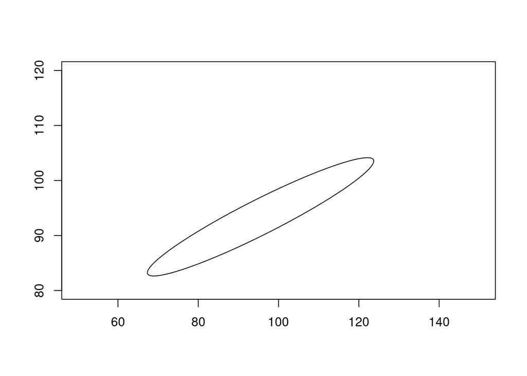

```r
plot(0, pch='',ylab='',xlab='',xlim=c(50,150),ylim=c(80,120))
draw.ellipse(x=means[1],y=means[2], a=lengths[1], b=lengths[2], angle=angle,deg=FALSE)
```

*C) Obtain $95%$ Bonferroni confidence intervals for the six means in Part a.* El intervalo de confianza del Bonferroni $100(1-\alpha)\%$ para $\mu_i$ es $\bar{x_i} \pm t_{n-1} (\frac{\alpha}{2p})\sqrt{\frac{S_{ii}}{n}}$

```r
m = 6

t_bon = qt(1-alpha/(2*m),df=n-1)

ui_b = c()
li_b = c()

for (i in 1:nrow(a)){
  ui_b <- append(ui_b, x_barra[i] + t_bon * sqrt(S[i,i]/n))
  li_b <- append(li_b, x_barra[i] - t_bon * sqrt(S[i,i]/n))
}

ui_b
```

```
## [1] 115.48669 173.76661  60.36771 101.00386  19.08199  32.74083
```

```r
li_b
```

```
## [1]  75.55331 154.99339  51.01229  85.77614  16.87801  29.51917
```

$115.48669 \ge \mu_1 \ge 75.55331$ $173.76661 \ge \mu_2 \ge 154.99339$ $60.36771 \ge \mu_3 \ge 51.01229$ $101.00386 \ge \mu_4 \ge 85.77614$ $19.08199 \ge \mu_5 \ge 16.87801$ $32.74083 \ge \mu_6 \ge 29.51917$

*D) Refer to part b. Construct the 95% Bonferroni confidence rectangle for the mean weight and mean girth using $m=6$. Compare this rectangle with the confidence ellipse in part b.*

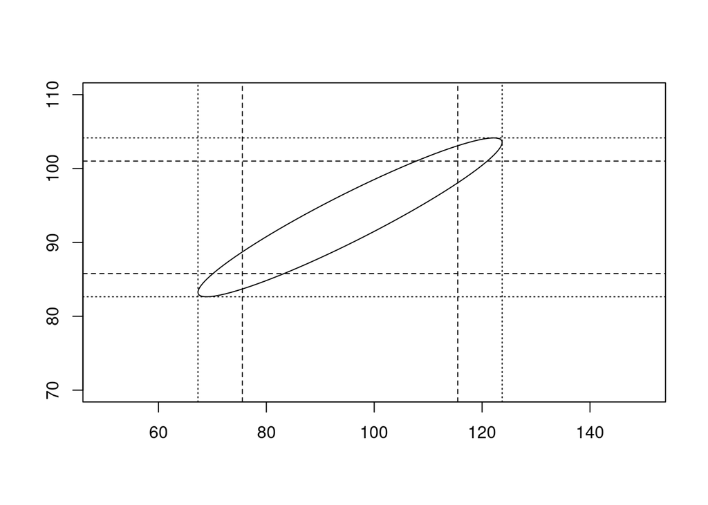

```r
plot(0,pch='',ylab='',xlab='',xlim=c(50,150),ylim=c(70,110))
draw.ellipse(x=x_barra[1],y=x_barra[4],a=lengths[1],b=lengths[2],angle=angle,deg=FALSE)

abline(v=li[1],lty=3);abline(v=ui[1],lty=3)
abline(h=li[4],lty=3);abline(h=ui[4],lty=3)


abline(v=li_b[1],lty=2);abline(v=ui_b[1],lty=2)
abline(h=li_b[4],lty=2);abline(h=ui_b[4],lty=2)
```